# Session 3: Data

GDP Growth Nowcasting Workshop — Jamaica

Diego A. Guerrero

2026-05-01

# Learning Objectives

- Retrieve data from **public APIs**
- Download website data.
- Download and process **Google Trends** search data
- Understand and download **NASA Nighttime Lights** satellite imagery
- Apply economic data preprocessing: **deflation**, **seasonal adjustment**, **growth rates**

# Scraping Economic Data

## Accessing Data on the Web

### Application Programming Interfaces (APIs)

- **Definition:** Structured gateways to query databases and retrieve data automatically.
- **Examples:**
  - [FRED API](https://fred.stlouisfed.org/docs/api/fred/) — US macro data
  - [World Bank Data API](https://datahelpdesk.worldbank.org/knowledgebase/topics/125589)
  - [IMF API](https://datahelp.imf.org/)

A key is typically required. Always read the documentation.

### FRED API

The `fredapi` library provides a Python interface to the Federal Reserve Economic Data:

```python
import pandas as pd
from fredapi import Fred

fred = Fred(api_key='YOUR_API_KEY_HERE')
sp500 = fred.get_series('SP500')
sp500 = pd.DataFrame(sp500, columns=["SP500"])
sp500.tail(5)
```

Install with: `conda install fredapi -y`

### Multiple Queries via Loop

```python
import requests
import pandas as pd

series   = ["SP500", "DJIA", "NASDAQCOM"]
api_key  = "YOUR_API_KEY_HERE"

df = pd.DataFrame()
for serie in series:
    url = (f"https://api.stlouisfed.org/fred/series/observations"
           f"?series_id={serie}&api_key={api_key}&file_type=json")
    resp = requests.get(url).json()
    dfi  = pd.DataFrame(resp["observations"])[["value", "date"]]
    dfi.set_index("date", inplace=True)
    dfi.index = pd.to_datetime(dfi.index)
    dfi.rename(columns={"value": f"fred_{serie}"}, inplace=True)
    dfi[f"fred_{serie}"] = pd.to_numeric(dfi[f"fred_{serie}"], errors="coerce")
    df = df.join(dfi, how="outer") if not df.empty else dfi
```

### Direct Web Requests

When no API is available, files can be retrieved via HTTP:

**Simple (pandas)**

```python
import pandas as pd

url = "https://example.com/data.csv"
df = pd.read_csv(url)
```

**With requests**

```python
import requests, pandas as pd
from io import StringIO

url = "https://example.com/data.csv"
response = requests.get(url)
if response.status_code == 200:
    df = pd.read_csv(StringIO(response.text))
```

### Advanced Requests and Headers

Most websites block automated requests. We add browser-style headers:

```python
import requests

hdr = {
    'User-Agent': (
        'Mozilla/5.0 (Windows NT 10.0; Win64; x64) '
        'AppleWebKit/537.36 (KHTML, like Gecko) '
        'Chrome/58.0.3029.110 Safari/537'
    )
}

url = "https://www.statinja.gov.jm"   # STATIN Jamaica
r = requests.get(url=url, verify=None, headers=hdr).content
```

`headers` — the website thinks the request comes from a browser `verify=None` — disables SSL certificate checking (use with care)

### Parsing HTML with Beautiful Soup

```python
from bs4 import BeautifulSoup
import requests

hdr = {"User-Agent": "Mozilla/5.0"}
url = "https://www.datazoa.com/data/table.asp?a=view&th=69E287AF0E&dzuuid=1835&uid=dzadmin"
r = requests.get(url=url, verify=None, headers=hdr).content
soup = BeautifulSoup(r, "html.parser")

# Find all downloadable CSV links
links = [
    link.get("href") for link in soup("a")
]
print(links[:5])
```

```
['/img/embed/embed.asp?sid=econaccounts/00001045&hash=69E287AF0E&rownum=1&altlabel=Total+Value+Added+at+Basic+Prices ', '/img/embed/embed.asp?sid=econaccounts/00001046&hash=69E287AF0E&rownum=2&altlabel=Agriculture+Forestry+%26+Fishing ', '/img/embed/embed.asp?sid=econaccounts/00001047&hash=69E287AF0…
```

# Google Trends

## Google Trends as an Economic Indicator

Tracks real-time public interest in search terms — useful proxy for:

- **Consumer demand**: searches for products, services, and retail brands
- **Labour market**: job-search activity
- **Tourism**: hotel and travel queries from potential visitors
- **Uncertainty**: searches for economic news terms

**Key property**: freely available, monthly, with near-zero publication lag.

### Relevant Literature

**Choi & Varian (2012)** *Predicting the Present with Google Trends*

Google Trends predicts current unemployment, auto sales, and tourist destination visits.

**Varian (2023)** *Nowcasting with Google Trends*

Best practice: include trends data alongside traditional indicators.

**Cebrian & Domenech (2024)** *Addressing Google Trends Inconsistencies*

Inconsistencies across queries require re-scaling.

### Jamaica Google Trends Keywords

Examples used in the nowcasting dataset:

- `jamaica jobs` / `jobs in jamaica`
- `jamaica tourism` / `airbnb jamaica`
- `jamaican dollar` / `remittance jamaica`
- `supermarket jamaica` / `gracekennedy`
- Retail brands, restaurant chains, tech products

Downloads are available at trends.google.com — export as CSV (monthly, country = Jamaica).

### Processing Google Trends Files

```python
import glob, re, pandas as pd
import os

PATH_RAW = "../data"

csv_files = glob.glob(os.path.join(PATH_RAW, "*multi*.csv"))

df0 = pd.DataFrame()
for csv in csv_files:
    dfi = pd.read_csv(csv, skiprows=1)
    dfi.rename(columns={"Month": "date"}, inplace=True)
    dfi["date"] = pd.to_datetime(dfi["date"])
    dfi.columns = [re.sub(r"\W+", "_", c).lower().strip("_")
                   for c in dfi.columns]
    dfi.set_index("date", inplace=True)
    df0 = pd.concat([df0, dfi], axis=1)

df0.columns = ["gt_" + c for c in df0.columns]
df0.to_csv(f"{PATH_RAW}/gtrends.csv")
print("Last date:", df0.index.max())
```

### Google Trends Data: Example

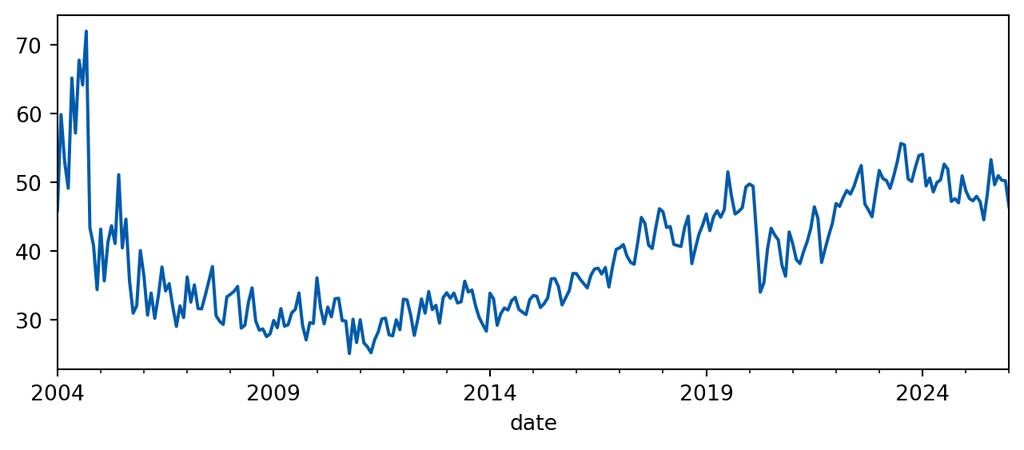

```python
import pandas as pd, numpy as np

PATH_RAW = "../data"
df = pd.read_csv(f"{PATH_RAW}/gtrends.csv",
                 parse_dates=True, index_col="date")

# Replace zeros with NaN (zero = no data, not zero activity)
df = df.replace(0, np.nan)

# Drop columns with >75% missing
df = df.dropna(axis=1, thresh=int(0.25 * len(df)))

# Create composite index (average across all terms)
df["gt_all_mean"] = df.mean(axis=1)

df["gt_all_mean"].plot(color="#005BAC", figsize=(8, 3))
```

# Satellite Nighttime Lights

## Why Nighttime Lights?

Satellite imagery of artificial light at night provides a proxy for:

- **Economic activity** — especially informal sector
- **Electrification and infrastructure**
- **Urban growth**

Available at fine spatial (500 m) and temporal (monthly) resolution. **No publication lag** — only processing delay.

## NTL in Jamaica

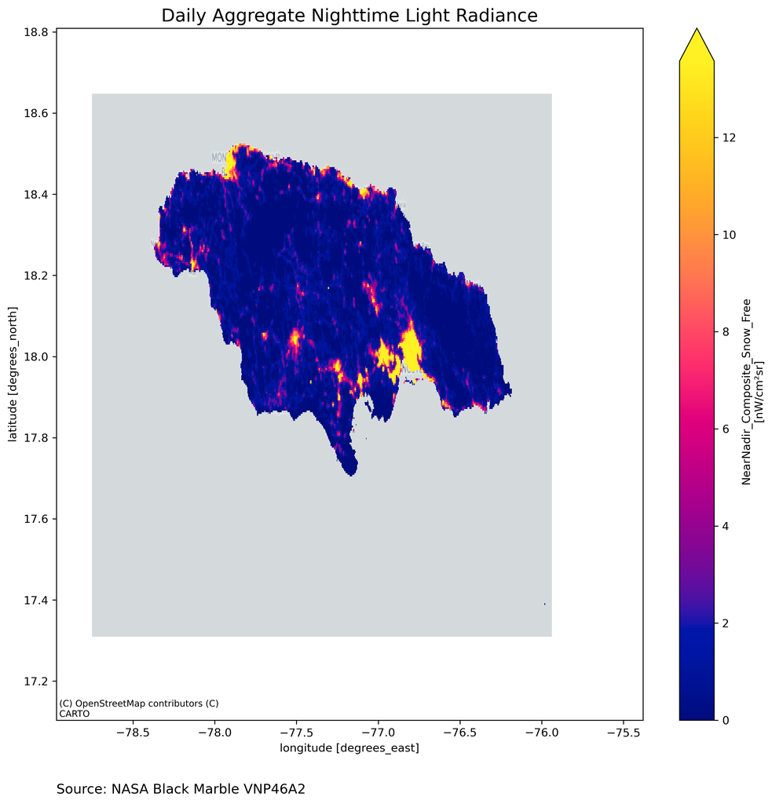

## NTL around Hurricane Melissa

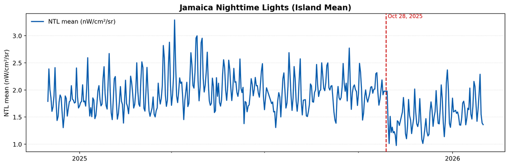

```python
import pandas as pd
import matplotlib.pyplot as plt
import matplotlib.dates as mdates

df_island = pd.read_csv('../workshop_code/notebook_files/data_ntl_island.csv', parse_dates=True, index_col='date')
event_date  = pd.Timestamp("2025-10-28")
event_label = "Oct 28, 2025"

fig, ax = plt.subplots(figsize=(12, 4))

ax.plot(df_island.index, df_island["ntl_mean"],
        color="#005BAC", linewidth=1.8, label="NTL mean (nW/cm²/sr)")

ax.axvline(event_date, color="#CC0000", linewidth=1.5, linestyle="--", zorder=3)
ax.text(event_date, ax.get_ylim()[1],
        f" {event_label}", color="#CC0000",
        fontsize=9, va="top", ha="left", rotation=0)

ax.set_title("Jamaica Nighttime Lights (Island Mean)", fontsize=13, weight="bold")
ax.set_ylabel("NTL mean (nW/cm²/sr)")
ax.xaxis.set_major_locator(mdates.YearLocator())
ax.xaxis.set_major_formatter(mdates.DateFormatter("%Y"))
ax.xaxis.set_minor_locator(mdates.MonthLocator(bymonth=[4, 7, 10]))
ax.grid(axis="y", linestyle=":", alpha=0.5)
ax.legend(frameon=False)
plt.tight_layout()
plt.show()
```

### NASA Black Marble VIIRS

- **Product**: VNP46A3 (monthly, cloud-free composite) and VNP46A2 (daily)
- **Variable**: Radiance in nW/cm²/sr
- **Coverage**: global, 500 m pixels, from 2012
- **Access**: NASA Earthdata — requires a free account and token
- **Python library**: `blackmarblepy` (run in the `geo` environment)

### Workflow Overview

1. **Register** at https://ladsweb.modaps.eosdis.nasa.gov/ — obtain a bearer token
2. **Download the shapefile** for Jamaica
3. **Run `blackmarblepy`** to download raster tiles (–we have an alternative process too)
4. **Aggregate** pixel values over Jamaica’s boundary
5. **Save** the data

## Downloading NTL with blackmarblepy

```python
# Run this in the geo environment: conda activate geo
import geopandas as gpd
import pandas as pd

# Load Jamaica boundary
shape = "https://geodata.ucdavis.edu/gadm/gadm4.1/shp/gadm41_JAM_shp.zip"
gdf = gpd.read_file(shape)
gdf.explore(tiles="CartoDB dark_matter", zoom=11)
```

Make this Notebook Trusted to load map: File -> Trust Notebook

[interactive chart not shown]

### Downloading Monthly Composite

```python
from blackmarble import BlackMarble
import pandas as pd
import geopandas as gpd

shape = "https://geodata.ucdavis.edu/gadm/gadm4.1/shp/gadm41_JAM_shp.zip"
gdf = gpd.read_file(shape)

token = "YOUR_EARTHDATA_TOKEN_HERE"
bm = BlackMarble(token=token)

# Download VNP46A3 monthly composite
df_ntl = bm.raster(
    gdf,
    product_id="VNP46A3",
    date_range=pd.date_range("2015-01-01", "2026-01-01", freq="ME"),
)

# Aggregate: sum all pixels over Jamaica
dfx = (
    df_ntl["NearNadir_Composite_Snow_Free"]
    .sum(dim=["x", "y"])
    .rename("NearNadir_Composite_Snow_Free")
    .to_dataframe()
)
dfx.index.name = "date"
dfx.to_csv("../data/blk_ntl.csv")
```

### Visualizing monthly NTL

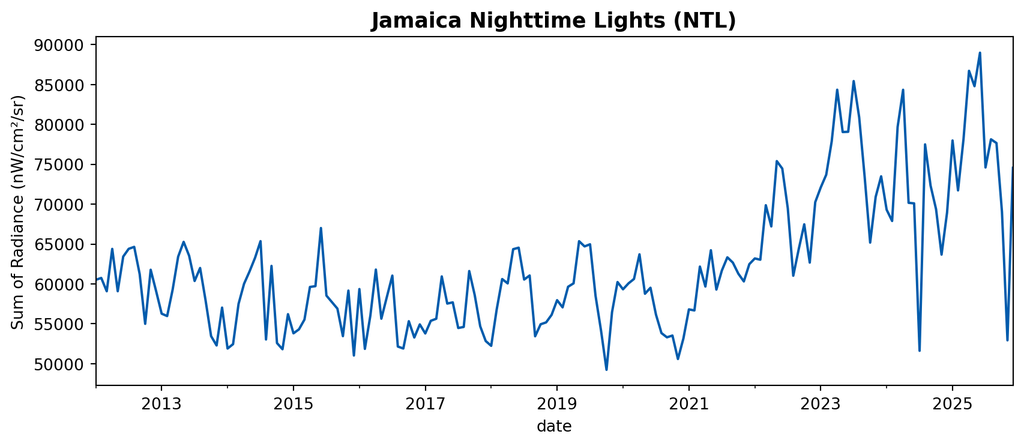

```python
import pandas as pd
import matplotlib.pyplot as plt

df = pd.read_csv("../data/blk_ntl.csv",
                 parse_dates=True, index_col="date")

df["NearNadir_Composite_Snow_Free"].plot(
    color="#005BAC", linewidth=1.5, figsize=(9, 4)
)
plt.title("Jamaica Nighttime Lights (NTL)", fontsize=13, weight="bold")
plt.ylabel("Sum of Radiance (nW/cm²/sr)")
plt.tight_layout()
plt.show()
```

# Economic Data Preprocessing

## Three Standard Transformations

| Step | Purpose | Method |
| --- | --- | --- |
| **Deflation** | Remove price-level changes | Divide by CPI, multiply by base-year CPI |
| **Seasonal Adjustment** | Remove calendar seasonality | `seasonal_decompose` trend component |
| **Growth rates** | Achieve stationarity | Quarter-over-quarter `pct_change()` |

# Activity

## Build the Merged Dataset

Open `workshop_code/s3_build.ipynb` and:

1. Download your very own Google Trends data and apply processing with `s3b_gtrends.ipynb` — replace zeros with NaN, drop sparse columns, compute `gt_all_mean`
2. Examine `s3c_blackmarble.ipynb` and `s3c_ntl.ipynb` to process h5 files into nighttime lights data.
3. Load `data.csv` and inspect the GDP series (`RGDP0000`)
4. Merge Google Trends and NTL into the main GDP DataFrame
5. Apply seasonal adjustment, and growth-rate transformation
6. Resample to quarterly
7. Visualize